# Лабораторная работа №8

Операционные системы

Осина В.А.

Российский университет дружбы народов, Москва, Россия

30 марта 2024 года

# Информация

## Докладчик

- Осина Виктория Александровна
- студентка группы НКАбд-04-23
- Российский университет дружбы народов
- 1132236006@pfur.ru
- https://github.com/urocean

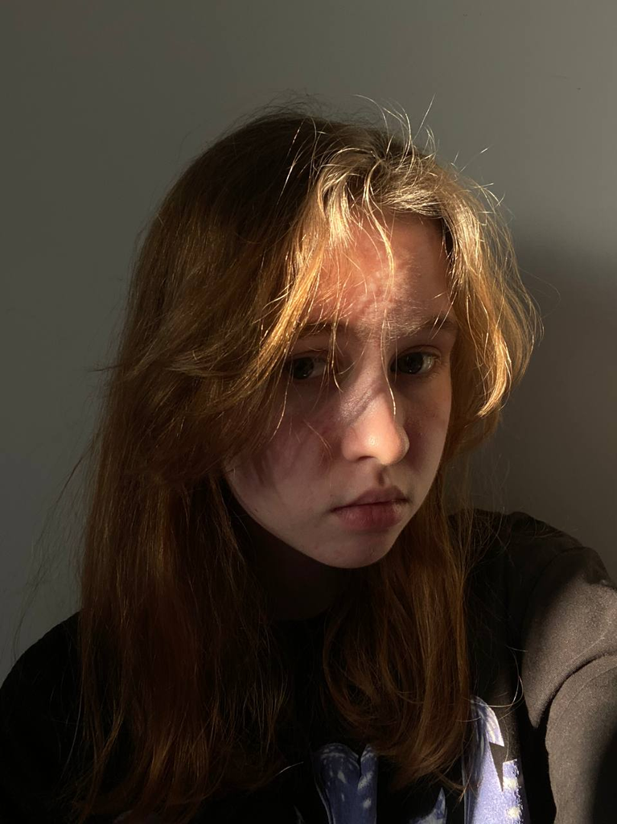

# Вводная часть

## Актуальность

- Важно уметь работать с консолью
- Знание нужных команд упростит работу с файлами

## Объект и предмет исследования

- Терминал
- Команды для терминала

## Цели и задачи

- Ознакомление с инструментами поиска файлов и фильтрации текстовых данных
- Приобретение навыков по управлению процессами и проверке использования диска и обслуживанию файловых систем

## Материалы и методы

- Терминал Linux

# Ход лабораторной работы

## Перенаправление элементов в файл

Записываю в файл file.txt названия файлов, содержащихся в каталоге /etc, при помощи перенаправления “>”, чтобы создать файл file.txt. Затем дописываю в этот же файл названия файлов, содержащихся в моём домашнем каталоге, используя перенаправление “>>”. Записываю имена всех файлов из file.txt, имеющих расширение .conf, в новый текстовой файл conf.txt и при помощи команды head вывожу первые 10 имен для проверки.

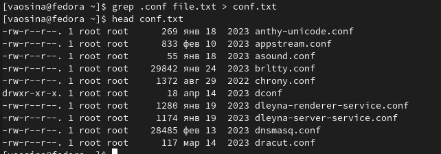

## Поиск файла и фильтрация текста

Определяю, какие файлы в моём домашнем каталоге имеют имена, начинающиеся с символа c. Вывожу на экран (по странично) имена файлов из каталога /etc, начинающиеся с символа h.

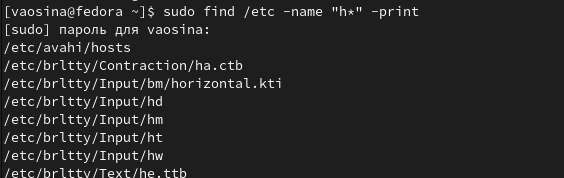

## Управление задачами и процессами,

Запускаю в фоновом режиме процесс, который будет записывать в файл ~/logfile файлы, имена которых начинаются с log. Удаляю файл ~/logfile. Запускаю из консоли в фоновом режиме редактор gedit. Использую команду kill для завершения процесса gedit.

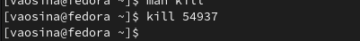

## Получение информации о процессах

Определяю идентификатор процесса gedit, используя команду ps, конвейер и фильтр grep.

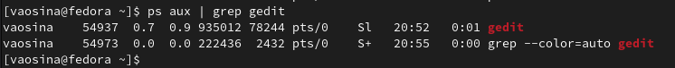

## Проверка использования диска

Выполняю команду df и du

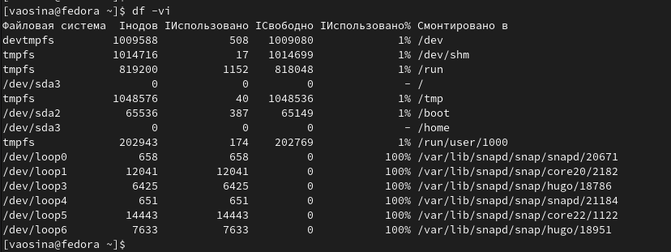

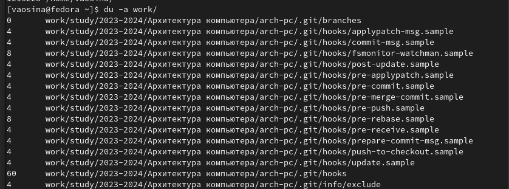

# Результаты

Благодаря данной лабораторной работе я ознакомилась с инструментами поиска файлов и фильтрации текстовых данныхм приобрела практические навыки: по управлению процессами (и заданиями), по проверке использования диска и обслуживанию файловых систем.

# Список литературы